# **LAB TWO: IMAGING**

This lab covers basic MR Imaging concepts: Gradients, Frequency Encoding, Phase Encoding, *k*-Space, Field of View, and Resolution.

#### **Required Resources**

For this lab you will need:

- ilumr fitted with 10mm RF Probe
- Shim Sample (#001)
- Phantom #002: Single thin layer of silicone
- Phantom #003: Multiple spaced out layers of silicone
- Phantom #004

#### **Setup Task: Run the Notebook**

> 1. Edit the cell below to set the `LAB_USER_NAME` variable to your name
> 2. Click **Run->Run All Cells** in the in top menu bar of jupyterlab
> 3. Open the Table of Contents side-bar on the left edge of jupyterlab to aid in navigation

**Important**: To initialise this notebook, edit the cell above to set `LAB_USER_NAME` to your name, then click **Run->Run All Cells** in the top menu bar.

```
Data will be saved to /home/data/REPLACE_ME/Lab 2
```

## 1. Gradients

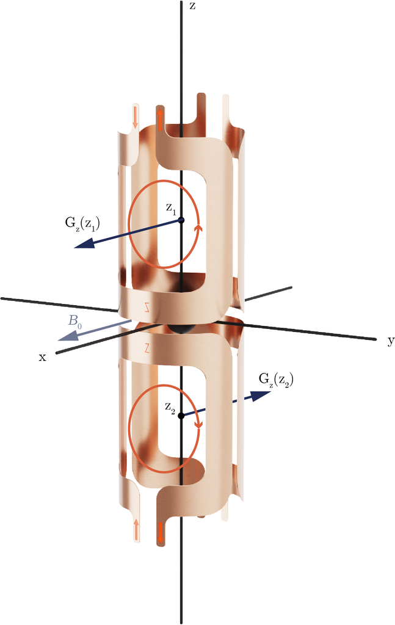

Figure 1.1: Z cradient coils and current directions (orange arrows). At $z_1$ the total field strength is increased, and at $z_2$ it is decreased.

In part of Lab One, we optimised the duration of the NMR signal by correcting the magnetic field inhomogeneities (unevenness) using shims. Inhomogeneity causes nuclei at different locations in the sample to resonate at slightly different frequencies, resulting in destructive interference and a reduction in signal duration. The fundamental principle of NMR imaging is to exploit the effect of inhomogeneity to locate the source of an NMR signal in space. To purposely distort the field in a way that is simple to analyse, we will use combinations of coils that create linear **gradients** in the the field strength along the $x$, $y$, and $z$ axes (see Figure 1.1).

Because the gradients are linear, the Larmor frequency at any location will be a linear function of its coordinate along the gradient axis, e.g. when applying gradient $G_z$:

$$ f = f_0 + \bar\gamma \cdot G_z \cdot z \tag{1.1}$$

Where $f_0$ is the Larmor frequency when no gradient is applied, and $\bar\gamma$ is the gyromagnetic ratio ($\bar\gamma = 42.58 \times 10^{6} \ \mathrm{Hz}/\mathrm{T}$).

In the next task, we will use the spin echo sequence shown below (Figure 1.2); first with the gradients set to the optimised shim values, and then modified to see how they can be used to encode position information into the NMR signal.

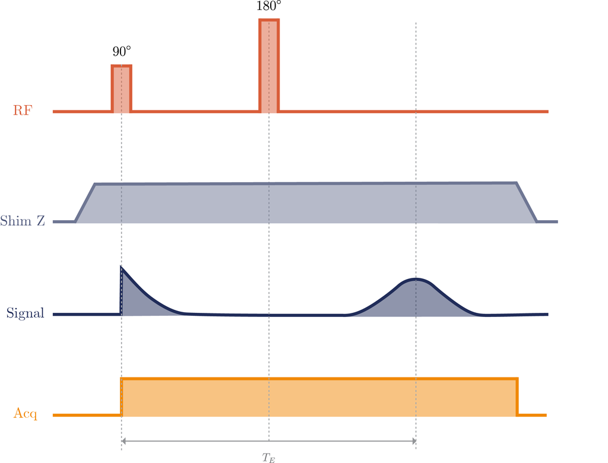

Figure 1.2: Spin Echo pulse sequence with the Z shim shown.

#### **Task 1.1**

> 1. Insert **Phantom #002** (make sure to centre the phantom using the depth gauge).
> 2. Reset shims and start experiment with **"Run Loop"**.
> 3. Zoom in on the echo signal (from 6ms to 14ms).
> 4. Move the phantom up and down. **Question:** What happens to the signal when it is moved too far from the centre?
> 5. Return the phantom to roughly the centre (where the signal returns to full amplitude).
> 6. Increase the Z shim to its limit (100% or -100%, whichever has more effect). **Question:** How does the signal shape change when the shim is offset?
> 7. Move the phantom up and down a small amount, so that the magnitude is not significantly affected. **Question:** What happens to the signal frequency?
> 8. Click abort to stop the experiment before moving on.

## 2. Frequency Encoding

### Theory

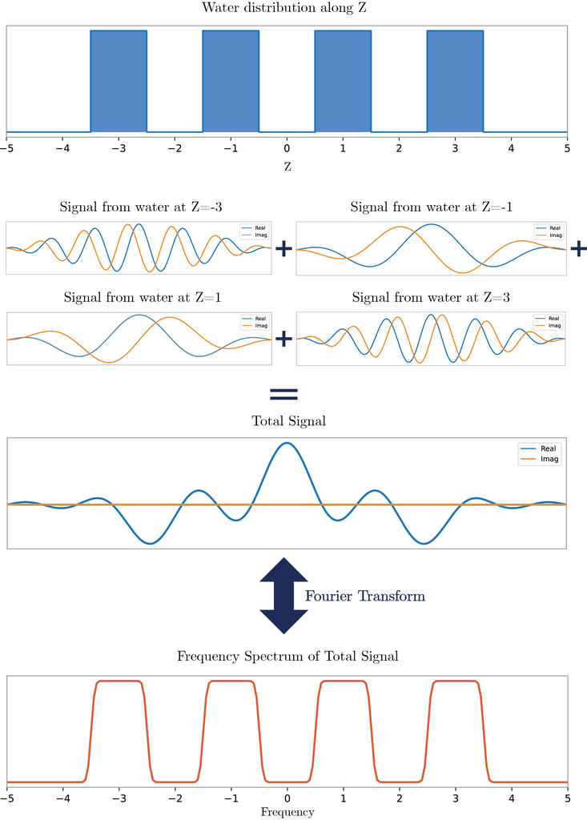

Figure 2.1: Frequency Encoding

The experiments in **Task 1.1** showed how the frequency of the NMR signal from a small sample varies with position when a gradient is applied by offsetting a shim value. In fact, with calibration to determine the value of $G_z$, the frequency can be measured and the position calculated by rearranging Equation 1.1.

Now consider a sample made up of multiple small partitions of fluid; each partition will emit a signal with frequency depending on its position, but the measured signal will be the sum of all of them, a complex shape caused by constructive and destructive intereference. The frequencies present in the measured signal can be extracted using a Fourier Transform, revealing individual peaks associated with the partitions (See Figure 2.1).

In this example the partitions of water are separated, but the same logic can be applied to a continuous shape. We can imagine slicing the sample into multiple slices along the gradient axis, so that the signals from the slices are similar to the signals from the partitions in Figure 2.1. When the total signal is measured and processed with a Fourier transform, the magnitude of the resulting spectrum at any frequency will be proportional to the amount of sample in the slice that is precessing at that frequency. This means the spectrum is a 1D projection image of the sample.

Mathematically, the total signal $s(t)$ we measure in the rotating frame is proportional to the integral of the magnetization $m(z)$ multiplied by a phasor contributed by the frequency shift caused by $G_z$:

$$ \large s(t) \propto \int_z m(z) e^{-i \bar\gamma G_z z t} dz \tag{2.1}$$

$$ \large m(z) \propto \int_t s(t) e^{i \bar\gamma G_z z t} dt \tag{2.2}$$

### Pulse Sequence

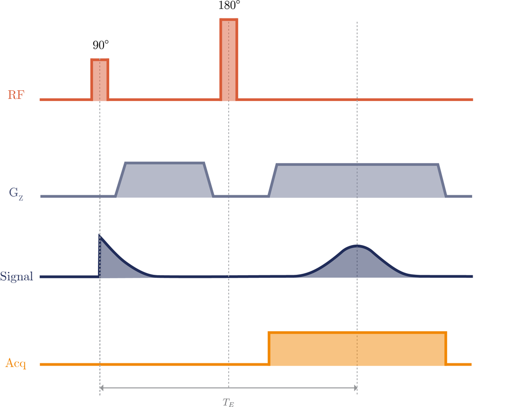

Figure 2.2: the Spin Echo sequence with a switched frequency encode gradient ($G_z$) and gated acquisition.

For simplicity, the shim values and gradient values are generally set seperately and added together by the hardware. The gradient also does not need to be active for the entire pulse sequence, only during the acquisition time and for a short time between the $90^\circ$ and $180^\circ$ RF pulses – to satisfy a requirement for optimal spin echo formation where the area under the gradient between the $90^\circ$ and $180^\circ$ pulses must match the area under the gradient from the $180^\circ$ to the echo time ($T_E$). This optimised pulse sequence is shown in Figure 2.2, and will be used in the next experiment.

#### **Task 2.1**

> 1. With **Phantom #002** still inserted, start the experiment with **"Run Loop"**.
> 2. Increase the read gradient to 25%.
> 3. Move the sample up and down again, and see how the spectrum changes. **Question:** Does this match your observations in the previous experiment?
> 4. Inspect **Phantom #003** and, based on your observations with **Phantom #002**, hand-draw a rough plot of the spectrum you would expect to see when it is inserted. **NOTE**: If the phantom is opaque you can shine a phone torch through it to see inside.
> 5. Insert **Phantom #003** (centred with the depth gauge). **Question:** Does the spectrum look as you expected?
> 6. Adjust the gradient strength through its possible range and note how the spectrum "image" changes. **Question:** Comparing the image with 25% gradient and 50% gradient: Which has a larger Field Of View (FOV)? Which has higher Signal-to-Noise Ratio (SNR)? Which has finer spatial resolution? (refer to the Image Characteristics section below)
> 7. Click abort to stop the experiment before moving on.

### Image Characteristics

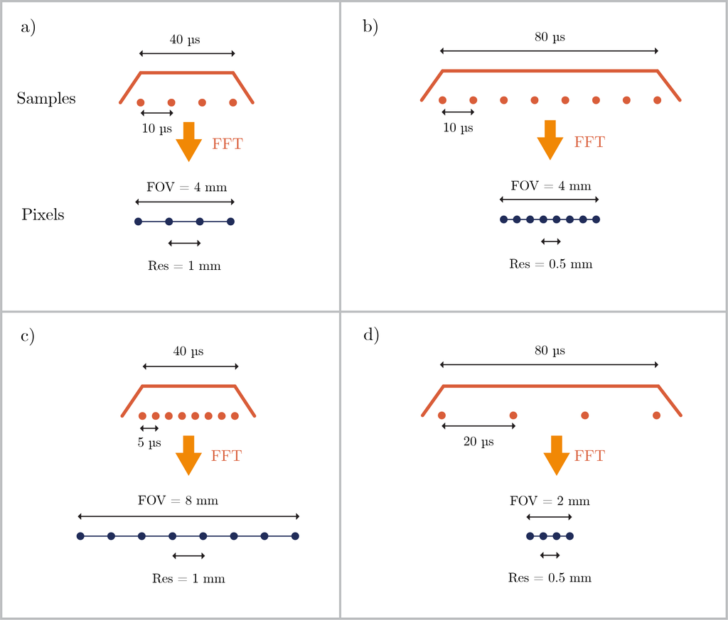

Figure 2.3: How Dwell Time (sample spacing) and Number of Samples affect FOV and Resolution, with a fixed frequency encode gradient amplitude.

Three important characteristics of an image are:

- **Field of View (FOV)**: The physical size of the image, i.e. the size of the largest object that can be viewed without being cropped or wrapped.
- **Spatial Resolution**: The level of detail, usually expressed as a minimum distance between features such that they are still resolved, and not merging into a single blob. Note that this is not the same as the number of pixels in the image (Pixel Resolution). e.g. a spatial resolution of 1 mm is *finer resolution* than a spatial resolution of 2 mm.
- **Signal to Noise Ratio (SNR)**: The ratio of the amplitude of the signal in areas of image corresponding to the nuclei in the sample to the amplitude of the noise in areas without signal. A larger SNR is better.

The relationship of FOV and resolution to the pulse sequence parameters, dwell time and number of samples, can be unintuitive. Figure 2.3 shows how, compared to (a): (b) increasing the number of samples with the same dwell time does not affect FOV and results in finer resolution; (c) increasing the number of samples while decreasing the dwell time to keep the total acquisition time the same increases the FOV without affecting resolution, and (d) increasing dwell time without changing the number of samples decreases FOV and gives finer resolution (zoom in).

## 3. Projection Reconstruction

With the above method of creating a 1D projection image, a 2D image can be reconstructed by combining multiple images with the sample rotated at different angles. This is the method used to produce 3D images from X-ray projections, called Computed Tomography (with the X-ray machine rotated around the human). If we apply a combination of linear gradients they will add together to produce a net gradient in an oblique (off-axis) direction. Using this method the gradient can be rotated instead of the rotating the sample.

In the next experiment, the read gradient will be specified with a magnitude $|G|$ and angle $\theta$, and the $x$ and $y$ components will be automatically calculated using:

$$ G_x = |G| \cdot \cos \theta \\ G_y = |G| \cdot \sin \theta \tag{3.1} $$

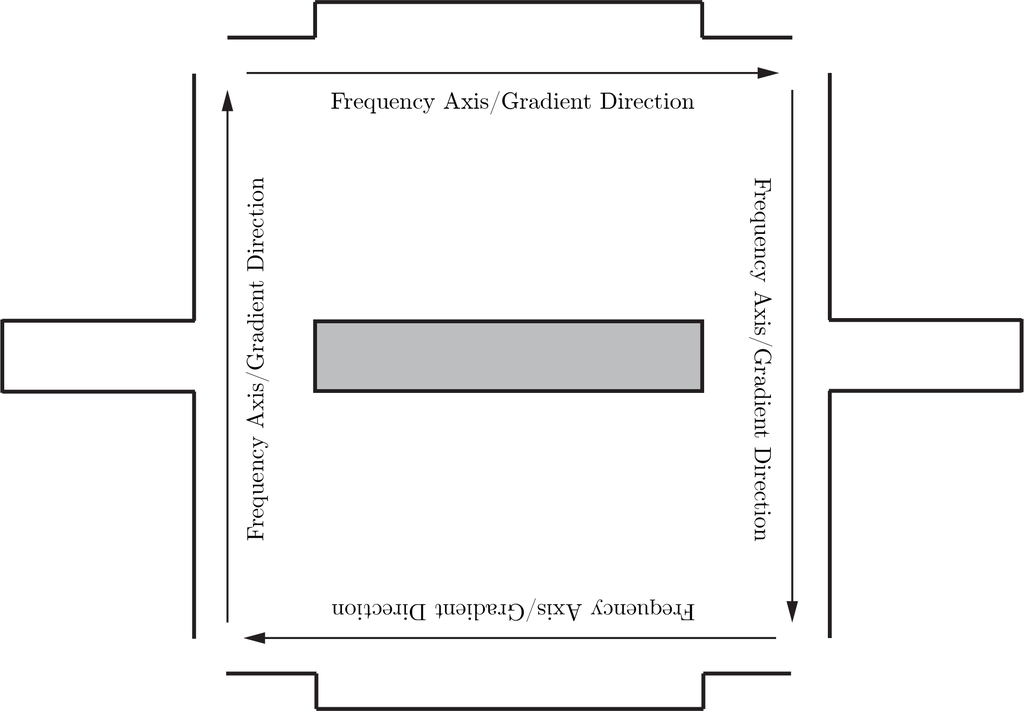

Figure 3.1: Projection Reconstruction

#### **Task 3.1**

> 1. Insert **Phantom #004** at the correct depth and start the experiment below with **"Run Loop"**.
> 2. Increase the magnitude to expand the 1D image and try both physically rotating the sample and rotating the read gradient direction.
> 3. Set the gradient magnitude appropriately so that the 1D image is not cropped with any gradient direction.
> 4. Based on the 1D views at different angles, draw a 2D top-down diagram of where you think the water is located in **Phantom #004**. Hint: draw a square in your notebook, and for each edge draw the 1D image you get from orienting the gradient along that edge. Based on this you can draw inside the square where the water is located (See Figure 3.1).
> 5. Click abort to stop the experiment before moving on.

## 4. 2D Imaging

### *k*-Space in 1D

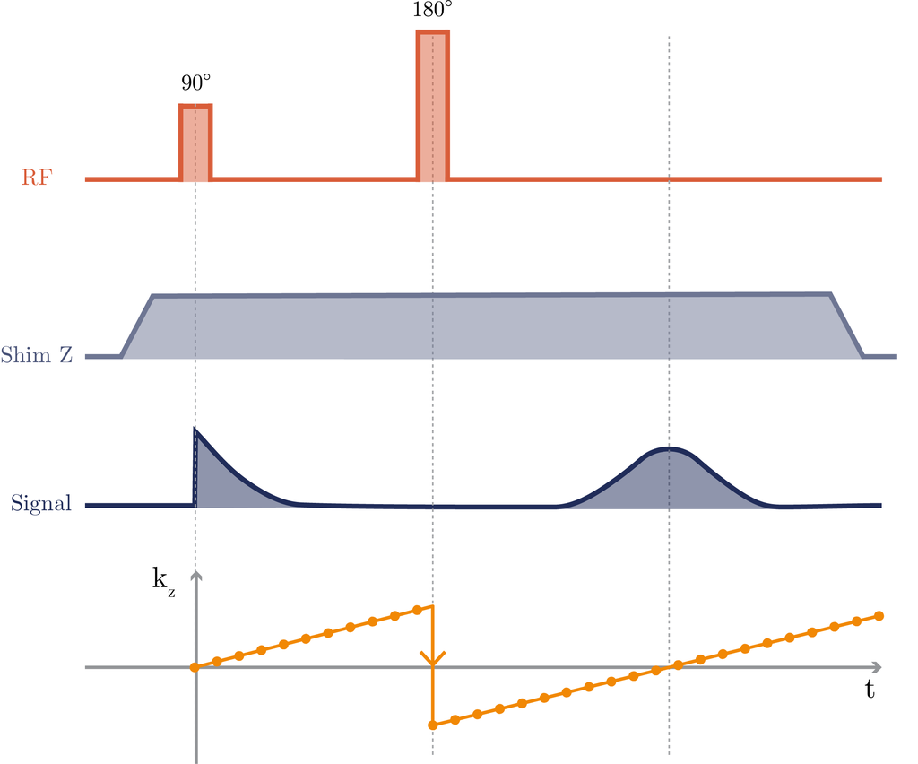

Figure 4.1: $k_z$ trajectory in a Spin Echo pulse sequence with a constant $z$ shim offset

The signal we acquire must generally be Fourier transformed to produce an image, and in order to understand how the pulse sequence and acquisition samples relate to the image obtained it is helpful to use the concept of *k*-space. A *k*-space image is the inverse Fourier transform of the image in physical space (the "normal" image). The value of a pixel in a *k*-space image represents the amount of a particular *spatial frequency* (units of radians per meter) in the physical space image, with the centre of *k*-space corresponding to low spatial frequencies and the edges to high spatial frequencies.

Every discrete sample acquired during the pulse sequence has a *k*-space coordinate depending on the gradients and RF pulses applied so far. For frequency encoding as used in the previous sections, $k_z$ evolves as shown in Figure 4.1. The $180^\circ$ RF pulse inverts the accumulated phase of nuclei that were excited by the initial $90^\circ$ pulse, which also inverts the *k*-space coordinate. The pulse sequence is designed so that after the $180^\circ$ pulse $k_z$ is negative and passes through zero at $T_E$ before becoming positive. In this way we sample along a line segment through *k*-space centred at $k_z=0$.

### *k*-Space in 2D

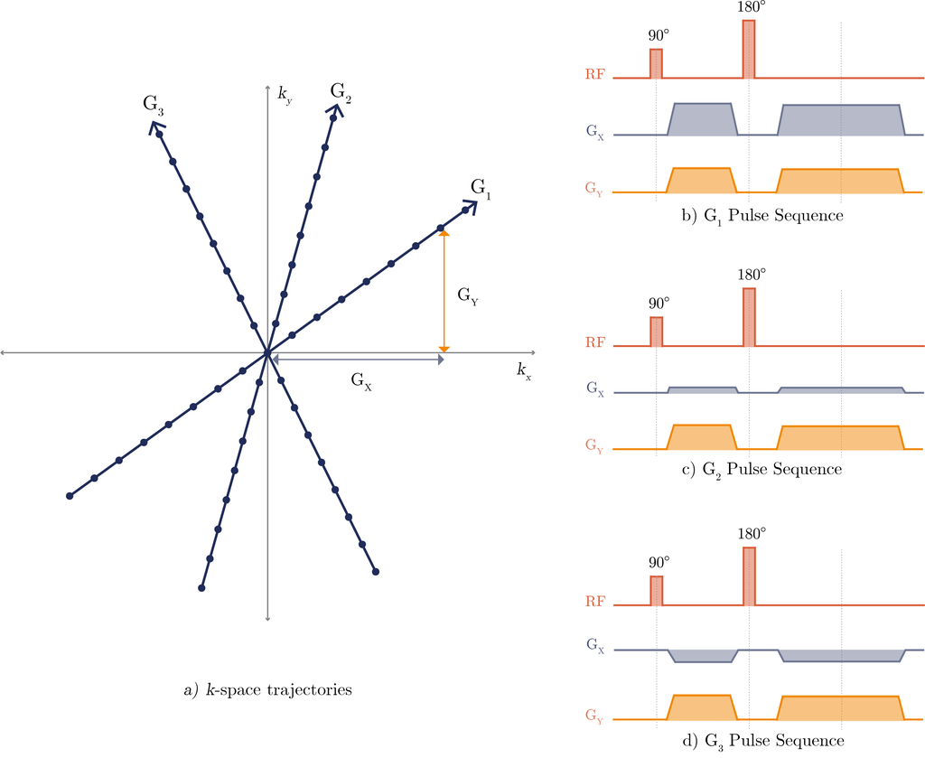

Figure 4.2: Projection Reconstruction $k$-space sampling

Sampling along a line segment in *k*-space produces a 1D image projected onto a line segment in physical space, and in **Section 3** it was possible to build a rough 2D image by combining multiple 1D projections. In *k*-space, the data acquired lies on line segments through the origin of 2D k-space as shown in Figure 4.2. In principle, instead of processing each line individually with a 1D Fourier transform, we can generalise and apply a 2D Fourier transform to our 2D *k*-space data. In practice this is difficult to do with the data from these line segments because they do not fall in a regular grid, and the Fast Fourier Transform algorithm cannot be used directly. There are advanced data processing techniques that can resample the data into a grid, but these will not be covered in this lab.

Instead, we will modify the pulse sequence as shown in Figure 4.3 to cause the *k*-space coordinates to fall into a regular grid. This is done using *phase encoding*, where a gradient pulse is applied before sampling, causing the accumulated phase of precession to change depending on position. After a $y$ gradient pulse with amplitude $G_y$ and duration $t_y$ the final phase at coordinate $y$ is:

$$ \phi = \bar\gamma G_y t_y \cdot y \tag{4.1}$$

In this way, the $y$ position can be determined from the phase of the signal of a small partition of sample. With a large sample, the signals from different $y$ locations will sum together into a single phase and magnitude, and multiple acquisitions stepping through values of $G_y t_y$ are required to fill the *k*-space grid as shown in Figure 4.4, so that the Fourier transform can be used to separate out the signals from different locations.

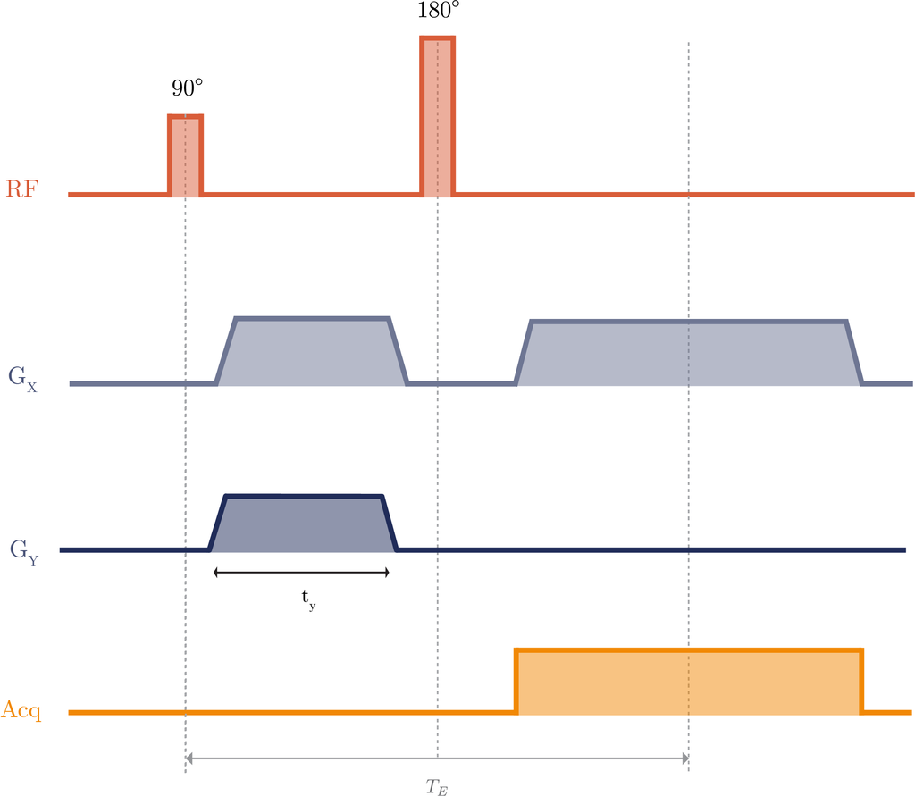

Figure 4.3: 2D Spin Echo imaging pulse sequence

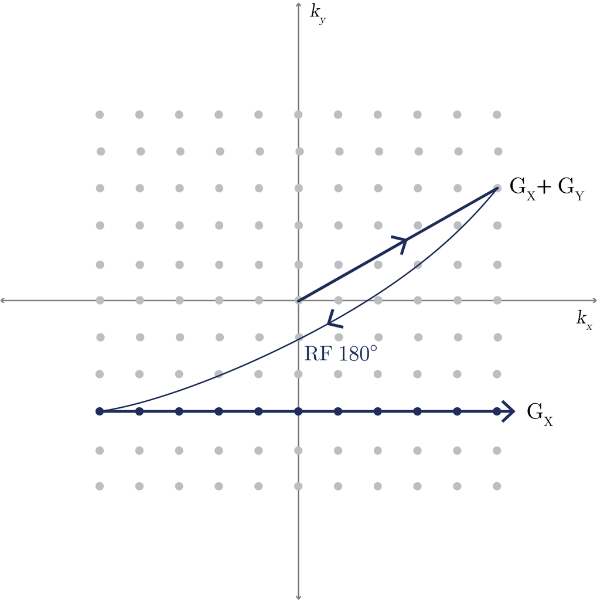

Figure 4.4: $k$-space trajectory of a single Spin Echo acquisition

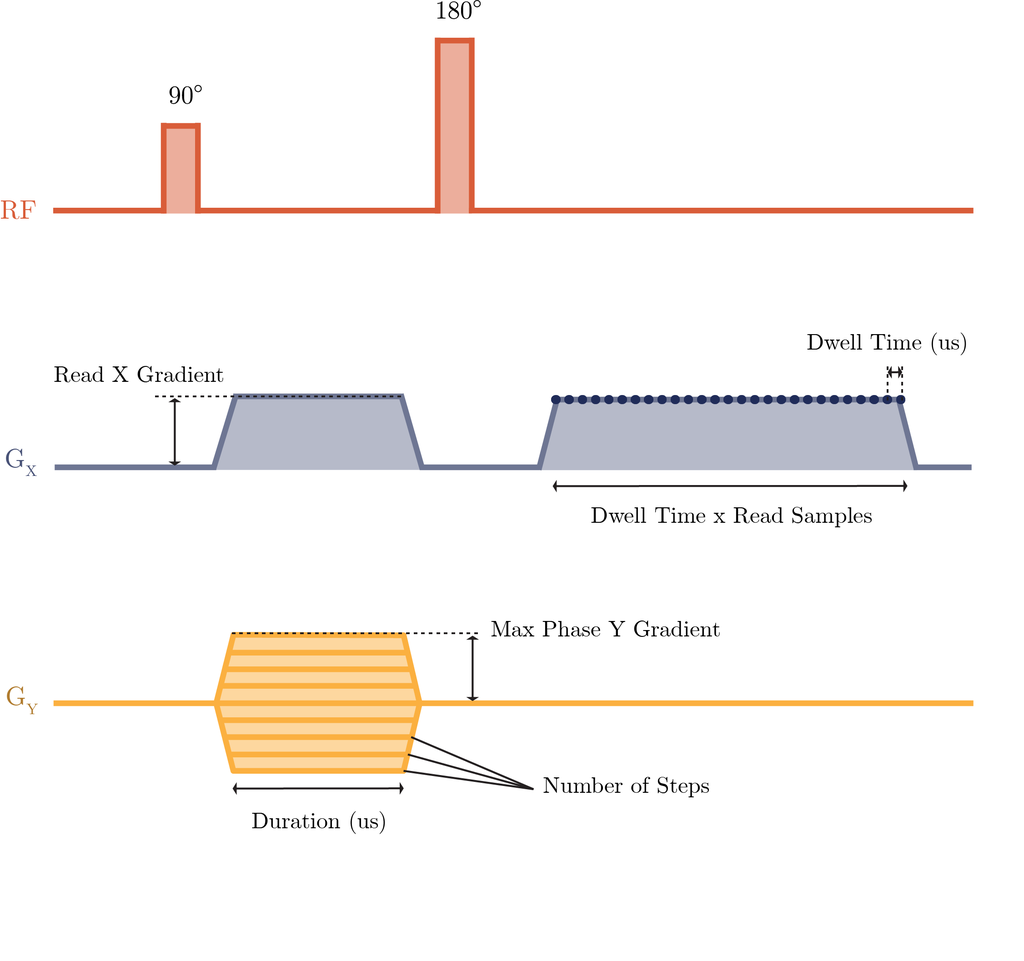

Figure 4.5: Parameters of the 2D Spin Echo imaging experiment

#### **Task 4.1**

> 1. Insert the **Shim Sample** at the correct depth.
> 2. Set the read and phase gradient values to a non-zero value and run the experiment.
> 3. As the experiment progresses, k-space will be filled one line at a time, and should end with a spectral pattern.
> 4. By modifying the gradient values, adjust the FOV in both directions so the image fills the plot on the right. Save the Image plot and record the gradient values used. Note: you can abort the experiment early while trying out values to save time.
> 5. Try increasing the read gradient to maximum. **Question**: what happens to the image?
> 6. Reset the read gradient to the value found in step 4, and try increasing the phase gradient to maximum. **Question**: what happens to the image now? Is it the same as when the read gradient was set too high?
> 7. Insert **Phantom #004** at the correct depth and run the experiment with the optimised gradient values. Save the Image plot. **Question**: Does the image match what you drew in **Task 3.1**?
> 8. Adjust the parameters to achieve an image with the same FOV but twice as fine resolution. Save the Image plot. *Hint: Refer back to the Image Characteristics section, and to Figure 4.5 on the right.*